# Laboratorio 1 - Exploración, preparación y regresión lineal

*Presentado por:*

- Shaiel Jimenez - 202323846
- Juan Esteban Triviño - 202315338

*ISIS2611 - Aprendizaje de Máquina / Sección 5*

*Profesor: Rubén Manrique*

**Table of contents**

- Laboratorio 1 - Exploración, preparación y regresión lineal
- Introducción
  - Resumen de los pasos realizados
- Exploración de los datos

# Introducción

Este laboratorio aborda el caso del Instituto AlpesPlanck, que registra variables meteorológicas en su estación de Jena, Alemania, y busca predecir la temperatura máxima del día siguiente para anticipar condiciones que puedan derivar en incendios forestales o en fenómenos como "El Niño" y "La Niña". A partir de estos datos, en este trabajo se aplica el ciclo de machine learning para explorar y preparar la información disponible, construir y comparar dos modelos de regresión lineal con distintas estrategias de preparación, evaluar su desempeño mediante las métricas RMSE, MAE y R², e identificar las variables meteorológicas que más aportan a la predicción, con el fin de generar conocimiento útil para la toma de decisiones frente a este tipo de fenómenos climáticos.

## Resumen de los pasos realizados

- **Exploración de datos:** nulos revisados (~2.4-3.7% por columna), duplicados de fecha identificados y resueltos, valores categóricos inconsistentes normalizados (`mes`, `estacion_anio`, `sector_viento`), errores de escala corregidos (`presion_media`, `humedad_media`, `humedad_min`), outliers físicamente imposibles eliminados (ráfaga negativa, componente de viento fuera de rango, registros/día > 144), correlación de variables numéricas con el target revisada.
- **Preparación de datos:** split train/test (75/25, `random_state=42`) hecho *antes* de imputar, para evitar fuga de datos; imputación de nulos (mediana/moda) ajustada solo con `X_train`.
- **Modelo 1 — estrategia de preparación:** solo variables numéricas (imputación por mediana + `StandardScaler`), sin categóricas. Línea base para medir el aporte real de las estrategias de preparación de los modelos 2 y 3.
- **Modelo 2 — estrategia de preparación:** se agregan `mes`, `estacion_anio` y `sector_viento` mediante One-Hot Encoding (`drop='first'` para evitar la trampa de variables dummy, `handle_unknown='ignore'` por seguridad).
- **Modelo 3 — estrategia de preparación:** además de lo del Modelo 2, se reemplaza la codificación lineal de `dia_del_anio` y `direccion_viento` (variables circulares) por una codificación cíclica seno/coseno, para que el modelo capture la continuidad diciembre→enero y la continuidad de la dirección del viento sin dejar de ser un modelo lineal.
- **Evaluación comparativa:** los tres modelos se comparan con RMSE, MAE y R² en train y test en `tabla_comparativa` (ver sección *Construcción de modelos de regresión lineal*).
- **Variables más importantes:** se extraen a partir de los coeficientes del Modelo 3 (`coef_df`), teniendo en cuenta que solo son directamente comparables en magnitud entre variables numéricas estandarizadas (las dummies de OHE y los pares seno/coseno se interpretan de forma distinta).
- **Predicciones sobre datos de prueba:** se generan con el modelo de menor RMSE en test (selección automática vía `tabla_comparativa["RMSE_test"].idxmin()`) y se visualizan con un gráfico real vs. predicho.

# Exploración de los datos

```python
import pandas as pd
import numpy as np
import sklearn
import matplotlib.pyplot as plt
import seaborn as sns
from sklearn.impute import SimpleImputer
from sklearn.model_selection import train_test_split
from sklearn.pipeline import Pipeline
from sklearn.compose import ColumnTransformer
from sklearn.preprocessing import StandardScaler, OneHotEncoder
from sklearn.linear_model import LinearRegression
from sklearn.metrics import mean_absolute_error, mean_squared_error, r2_score
```

# Carga Inicial de datos

```python
# cargar los datos empleando pandas
df = pd.read_csv('data/Datos Lab 1.csv')
data = df.copy()

df.shape
```

```
(2576, 27)
```

## Revision y tratamiento de datos

```python
((data.isnull().sum()/data.shape[0])).sort_values(ascending=False)
```

```
temp_max_manana      0.036879
viento_min           0.035326
mes                  0.034161
estacion_anio        0.034161
anio                 0.033385
humedad_max          0.033385
viento_media         0.033385
viento_max           0.031444
presion_desv         0.031056
humedad_min          0.031056
viento_norte         0.031056
rafaga_desv          0.030668
direccion_viento     0.030668
rafaga_media         0.030280
registros_del_dia    0.029891
presion_media        0.029115
humedad_media        0.028727
presion_min          0.028727
rafaga_max           0.028339
rafaga_min           0.027950
viento_desv          0.027950
fecha                0.027950
sector_viento        0.027562
dia_del_anio         0.026398
viento_este          0.024845
presion_max          0.024845
humedad_desv         0.023680
dtype: float64
```

```python
# Si fecha es nulo se podria eliminar dado que no tiene sentido imputar una fecha, ademas de que es una columna que no aporta informacion para el analisis de los datos.

data = data.dropna(subset=['fecha'])

# Agrupar columnas numericas y categoricas (se usan mas adelante)

num_cols = data.select_dtypes(include=np.number).columns

cat_cols = data.select_dtypes(include='object').columns

# NOTA IMPORTANTE: la imputación estadística (mediana / moda) de estas columnas
# se difiere hasta DESPUÉS de hacer el split train/test. Si imputáramos ahora,
# sobre el 100% de los datos, la mediana/moda usada para llenar valores en el
# futuro conjunto de train ya habría "visto" filas que terminan en test → fuga
# de datos. La imputación real se hace más abajo, ajustando el imputador
# únicamente con datos de entrenamiento.
```

```python
((data.isnull().sum()/data.shape[0])).sort_values(ascending=False)
```

```
temp_max_manana      0.037141
viento_min           0.035144
mes                  0.034744
estacion_anio        0.034744
viento_media         0.033546
anio                 0.033147
humedad_max          0.031949
viento_max           0.031550
presion_desv         0.031150
rafaga_desv          0.030751
registros_del_dia    0.030751
direccion_viento     0.030751
rafaga_media         0.030351
viento_norte         0.029952
humedad_min          0.029952
presion_media        0.029553
humedad_media        0.029553
presion_min          0.029153
rafaga_min           0.027955
viento_desv          0.027955
sector_viento        0.027556
rafaga_max           0.027157
dia_del_anio         0.026757
presion_max          0.024361
viento_este          0.023962
humedad_desv         0.023962
fecha                0.000000
dtype: float64
```

## Corrección de inconsistencias en variables categóricas

Al revisar los valores únicos de `mes`, `estacion_anio` y `sector_viento` se encontró que **no son datos limpios**, aunque no tengan valores nulos:

- **`mes`**: 60 valores únicos para 12 meses reales (mayúsculas/minúsculas y español/inglés mezclados: `APRIL`, `Apr`, `abril`, `april`, `April`...).
- **`estacion_anio`**: 28 valores para 4 estaciones. Incluye errores de tipeo (`primaveraa`, `berano`, `invernio`, `verno`), espacios extra, y valores que **no son estaciones válidas**: `'East'` (una dirección de viento mal ubicada en esta columna), `'Estacion_Desconocida'` (un valor centinela explícito de dato desconocido) y `'VERANO_INVIERNO'` (una combinación sin sentido). Estos tres casos se tratan como **valores faltantes** en vez de forzar un mapeo arbitrario, porque no hay forma confiable de inferir la estación real a partir de ellos.
- **`sector_viento`**: 31 valores para 8 direcciones cardinales, mismo problema de formato.

Se normalizan a un conjunto reducido y consistente de categorías antes de continuar, porque de lo contrario el imputador de moda (`most_frequent`) y cualquier encoding posterior tratarían, por ejemplo, `"april"` y `"APRIL"` como categorías distintas.

```python
import re

def normaliza(s):
    if pd.isna(s):
        return s
    s = str(s).strip().lower()
    s = re.sub(r'[^a-záéíóúñ]', '', s)
    return s

# --- mes: 12 meses en español, sin importar idioma/formato de entrada ---
meses_map = {
    'enero': 'enero', 'jan': 'enero', 'january': 'enero',
    'febrero': 'febrero', 'feb': 'febrero', 'february': 'febrero',
    'marzo': 'marzo', 'mar': 'marzo', 'march': 'marzo',
    'abril': 'abril', 'apr': 'abril', 'april': 'abril',
    'mayo': 'mayo', 'may': 'mayo',
    'junio': 'junio', 'jun': 'junio', 'june': 'junio',
    'julio': 'julio', 'jul': 'julio', 'july': 'julio',
    'agosto': 'agosto', 'aug': 'agosto', 'august': 'agosto',
    'septiembre': 'septiembre', 'sep': 'septiembre', 'sept': 'septiembre', 'september': 'septiembre',
    'octubre': 'octubre', 'oct': 'octubre', 'october': 'octubre',
    'noviembre': 'noviembre', 'nov': 'noviembre', 'november': 'noviembre',
    'diciembre': 'diciembre', 'dec': 'diciembre', 'december': 'diciembre',
}
data['mes'] = data['mes'].apply(normaliza).map(meses_map)

# --- estacion_anio: 4 estaciones en español; garbage -> NaN (se imputa después) ---
estacion_map = {
    'invierno': 'invierno', 'winter': 'invierno', 'invernio': 'invierno', 'inverano': 'invierno',
    'primavera': 'primavera', 'spring': 'primavera', 'primav': 'primavera', 'primaveraa': 'primavera',
    'verano': 'verano', 'summer': 'verano', 'berano': 'verano', 'verno': 'verano',
    'otono': 'otono', 'autumn': 'otono', 'fall': 'otono', 'otoño': 'otono',
}
data['estacion_anio'] = data['estacion_anio'].apply(normaliza).map(estacion_map)  # no match -> NaN

# --- sector_viento: 8 puntos cardinales en español abreviado ---
sector_map = {
    'n': 'N', 'north': 'N', 'norte': 'N',
    'ne': 'NE', 'northeast': 'NE', 'noreste': 'NE',
    'e': 'E', 'east': 'E', 'este': 'E',
    'se': 'SE', 'southeast': 'SE', 'sureste': 'SE',
    's': 'S', 'south': 'S', 'sur': 'S',
    'so': 'SO', 'southwest': 'SO', 'suroeste': 'SO',
    'o': 'O', 'west': 'O', 'oeste': 'O',
    'no': 'NO', 'northwest': 'NO', 'noroeste': 'NO',
}
data['sector_viento'] = data['sector_viento'].apply(normaliza).map(sector_map)

print('mes:', sorted(data['mes'].dropna().unique()))
print()
print('estacion_anio:', sorted(data['estacion_anio'].dropna().unique()))
print('  -> nuevos NaN por valores no reconocidos:', data['estacion_anio'].isna().sum())
print()
print('sector_viento:', sorted(data['sector_viento'].dropna().unique()))
```

```
mes: ['abril', 'agosto', 'diciembre', 'enero', 'febrero', 'julio', 'junio', 'marzo', 'mayo', 'noviembre', 'octubre', 'septiembre']

estacion_anio: ['invierno', 'otono', 'primavera', 'verano']
  -> nuevos NaN por valores no reconocidos: 255

sector_viento: ['E', 'N', 'NE', 'NO', 'O', 'S', 'SE', 'SO']
```

## Corrección de errores de magnitud/escala en variables numéricas

Ambas correcciones se basan en el rango físicamente plausible de cada variable, no en un criterio estadístico de outliers (evita confundir "dato mal capturado" con "día real de clima extremo").

```python
print('Antes de corregir:')
print('  presion_media > 5000:', (data['presion_media'] > 5000).sum())
print('  humedad_media <= 1  :', (data['humedad_media'] <= 1).sum())
print('  humedad_min <= 1    :', (data['humedad_min'] <= 1).sum())

mask_presion = data['presion_media'] > 5000
data.loc[mask_presion, 'presion_media'] = data.loc[mask_presion, 'presion_media'] / 10

mask_hum_media = data['humedad_media'] <= 1
data.loc[mask_hum_media, 'humedad_media'] = data.loc[mask_hum_media, 'humedad_media'] * 100

mask_hum_min = data['humedad_min'] <= 1
data.loc[mask_hum_min, 'humedad_min'] = data.loc[mask_hum_min, 'humedad_min'] * 100

print('\nDespués de corregir:')
print('  presion_media > 5000:', (data['presion_media'] > 5000).sum())
print('  humedad_media <= 1  :', (data['humedad_media'] <= 1).sum())
print('  humedad_min <= 1    :', (data['humedad_min'] <= 1).sum())
print()
print(data[['presion_media', 'humedad_media', 'humedad_min']].describe())
```

```
Antes de corregir:
  presion_media > 5000: 6
  humedad_media <= 1  : 755
  humedad_min <= 1    : 605

Después de corregir:
  presion_media > 5000: 0
  humedad_media <= 1  : 26
  humedad_min <= 1    : 0

       presion_media  humedad_media  humedad_min
count    2430.000000    2430.000000  2429.000000
mean      989.136877      75.217926    59.928945
std         8.036440      13.891347    18.195759
min       948.996000       0.466265     1.003387
25%       984.278675      67.475750    45.550000
50%       989.432450      76.818800    58.890000
75%       994.373150      84.504300    72.500000
max      1011.653800     100.000000   103.311405
```

## Duplicados

```python
n_duplicados = int(data.duplicated(keep=False).sum())
print(f"Número de registros duplicados: {n_duplicados}")

# Eliminar registros duplicados
data = data.drop_duplicates(keep='first')

n_duplicados_rev = int(data.duplicated(keep=False).sum())
print(f"Número de registros duplicados: {n_duplicados_rev}")

# ¿Hay fechas que se repiten?
dup_fechas = (data['fecha'].value_counts()
                            .loc[lambda s: s > 1]
                            .sort_values(ascending=False))
print(f"Fechas duplicadas: {len(dup_fechas)}")

for fecha, n in dup_fechas.items():
    print(f"Fecha={fecha} → {n} apariciones")
```

```
Número de registros duplicados: 8
Número de registros duplicados: 0
Fechas duplicadas: 14
Fecha=2009-03-05 → 2 apariciones
Fecha=2009-05-02 → 2 apariciones
Fecha=2009-12-08 → 2 apariciones
Fecha=2010-08-14 → 2 apariciones
Fecha=2010-10-25 → 2 apariciones
Fecha=2012-10-04 → 2 apariciones
Fecha=2012-10-06 → 2 apariciones
Fecha=2012-11-22 → 2 apariciones
Fecha=2013-01-02 → 2 apariciones
Fecha=2013-05-29 → 2 apariciones
Fecha=2015-01-07 → 2 apariciones
Fecha=2015-02-03 → 2 apariciones
Fecha=2015-05-11 → 2 apariciones
Fecha=2015-12-07 → 2 apariciones
```

```python
data['fecha'] = pd.to_datetime(data['fecha'])

# Filas donde el año no coincide con la fecha
inconsistentes = data[data['anio'] != data['fecha'].dt.year]
print(inconsistentes.shape[0])
inconsistentes
```

```
83
```

|  | fecha | presion_media | presion_min | presion_max | presion_desv | humedad_media | humedad_min | humedad_max | humedad_desv | viento_media | ... | viento_norte | viento_este | direccion_viento | registros_del_dia | anio | dia_del_anio | estacion_anio | mes | sector_viento | temp_max_manana |
| --- | --- | --- | --- | --- | --- | --- | --- | --- | --- | --- | --- | --- | --- | --- | --- | --- | --- | --- | --- | --- | --- |
| 25 | 2009-01-26 | 977.2310 | 975.000000 | 980.89 | 1.7438 | 96.5639 | 95.20 | 97.5 | 0.5982 | 1.40990 | ... | 1.0684 | 0.3670 | 18.9574 | 144.0 | NaN | 26.0 | verano | septiembre | N | -1.04 |
| 30 | 2009-01-31 | 994.3756 | 989.950000 | 997.42 | 2.0522 | 88.4403 | 73.30 | 94.4 | 5.4441 | 2.58660 | ... | 1.9530 | 1.6026 | 39.3705 | 144.0 | NaN | 31.0 | invierno | abril | NE | NaN |
| 121 | 2009-05-02 | 998.1189 | 995.990000 | 999.41 | 0.9205 | 77.5000 | 51.09 | 99.6 | 18.9020 | 1.84440 | ... | NaN | 0.4668 | 23.7431 | 144.0 | NaN | 122.0 | primavera | octubre | NaN | 20.89 |
| 132 | 2009-05-13 | 992.3840 | 989.590000 | 995.05 | 1.8406 | 59.6700 | 44.88 | 75.7 | 10.2773 | 2.52420 | ... | 1.3270 | 1.3113 | 44.6575 | 144.0 | NaN | 133.0 | primavera | julio | NE | 17.84 |
| 163 | 2009-06-13 | 993.6042 | 992.800000 | 994.35 | 0.4078 | 55.8449 | 30.51 | 88.2 | 18.8033 | 6.93864 | ... | -0.2299 | -1.5106 | 261.3481 | 144.0 | NaN | 164.0 | invierno | diciembre | O | 23.83 |
| ... | ... | ... | ... | ... | ... | ... | ... | ... | ... | ... | ... | ... | ... | ... | ... | ... | ... | ... | ... | ... | ... |
| 2502 | 2015-11-08 | 999.8046 | 994.720000 | 1003.60 | 2.3725 | 74.3412 | 55.68 | 90.7 | 9.0097 | 5.54148 | ... | -0.9200 | -0.7359 | 218.6565 | 144.0 | NaN | 312.0 | otono | octubre | SO | 17.71 |
| 2536 | 2015-12-12 | 994.6981 | 998.714406 | 990.12 | 1.7716 | 80.6446 | 65.92 | 92.2 | 7.5439 | 2.24340 | ... | -1.4604 | -1.1378 | 217.9235 | 144.0 | NaN | 346.0 | invierno | diciembre | SO | 9.93 |
| 2551 | 2015-12-27 | 1000.5291 | 999.460000 | 1003.12 | 1.0983 | 77.0684 | 61.91 | 87.6 | 7.6486 | 2.63670 | ... | -2.3958 | -0.5269 | 192.4034 | 144.0 | NaN | 361.0 | invierno | diciembre | S | 9.72 |
| 2552 | 2015-12-28 | 1003.5725 | 1002.350000 | 1004.96 | 0.7294 | 87.1097 | 72.10 | 97.7 | 7.5170 | 3.02724 | ... | -0.6644 | -0.0853 | 187.3193 | 144.0 | NaN | 362.0 | verano | marzo | S | 9.16 |
| 2555 | 2015-12-31 | 996.9224 | 995.010000 | 999.20 | 1.4003 | 72.6064 | 49.56 | 97.4 | 17.6803 | 3.11310 | ... | -3.0401 | 0.1673 | 176.8493 | 144.0 | NaN | 365.0 | invierno | NaN | S | 2.72 |

83 rows × 27 columns

```python
data = data[data['anio'] == data['fecha'].dt.year]
print(data.shape)
```

```
(2417, 27)
```

```python
dup_fechas_rev = (data['fecha'].value_counts()
                                .loc[lambda s: s > 1]
                                .sort_values(ascending=False))
print(f"Fechas duplicadas restantes: {len(dup_fechas_rev)}")
```

```
Fechas duplicadas restantes: 12
```

```python
dup_table_rev = (
    data[data['fecha'].duplicated(keep=False)]
    .copy()
    .assign(repeticiones=data.groupby('fecha')['fecha'].transform('size'))
    .sort_values(['fecha'])
)
dup_table_rev
```

|  | fecha | presion_media | presion_min | presion_max | presion_desv | humedad_media | humedad_min | humedad_max | humedad_desv | viento_media | ... | viento_este | direccion_viento | registros_del_dia | anio | dia_del_anio | estacion_anio | mes | sector_viento | temp_max_manana | repeticiones |
| --- | --- | --- | --- | --- | --- | --- | --- | --- | --- | --- | --- | --- | --- | --- | --- | --- | --- | --- | --- | --- | --- |
| 63 | 2009-03-05 | 959.860700 | 958.67000 | 962.54 | 0.8964 | 94.294400 | 86.00 | 97.8 | 2.8296 | 1.29080 | ... | 0.1826 | 9.3166 | 144.0 | 2009.0 | 64.0 | primavera | julio | N | 5.370000 | 2 |
| 2574 | 2009-03-05 | 959.860700 | 958.67000 | 962.54 | 0.8964 | NaN | 86.00 | 97.8 | 2.8296 | 1.29080 | ... | 0.1826 | 9.3166 | 144.0 | 2009.0 | 64.0 | primavera | julio | N | 5.956009 | 2 |
| 2575 | 2009-12-08 | 983.849000 | 979.45000 | 991.40 | 3.7836 | 1.021309 | 80.10 | 96.8 | 5.9641 | 4.53492 | ... | NaN | 233.2095 | 144.0 | 2009.0 | 342.0 | verano | enero | SO | 7.120000 | 2 |
| 341 | 2009-12-08 | 983.849000 | 979.45000 | 991.40 | 3.7836 | 87.795100 | 80.10 | 96.8 | 5.9641 | 4.53492 | ... | -0.8314 | 233.2095 | 144.0 | 2009.0 | 342.0 | verano | enero | SO | 7.120000 | 2 |
| 590 | 2010-08-14 | 990.482800 | 989.22000 | 991.29 | 0.4346 | 84.386400 | 65.12 | 95.7 | 9.4681 | 1.70860 | ... | 0.6511 | 39.5952 | 144.0 | 2010.0 | 226.0 | verano | agosto | NE | 19.500000 | 2 |
| 2566 | 2010-08-14 | 991.272748 | 989.22000 | 991.29 | 0.4346 | 84.386400 | 65.12 | 95.7 | 9.4681 | 1.70860 | ... | 0.6511 | 39.5952 | 144.0 | 2010.0 | 226.0 | verano | agosto | NE | 19.500000 | 2 |
| 662 | 2010-10-25 | 992.877200 | 986.97000 | 998.17 | 3.4396 | 79.714900 | 62.70 | 94.3 | 9.2834 | 5.98716 | ... | -1.2591 | 251.2583 | 144.0 | 2010.0 | 298.0 | otono | octubre | O | 7.340000 | 2 |
| 2562 | 2010-10-25 | 992.877200 | 986.97000 | 998.17 | 3.4396 | 79.714900 | NaN | 94.3 | 9.2834 | 5.98716 | ... | -1.2591 | 251.2583 | 144.0 | 2010.0 | 298.0 | otono | octubre | O | 7.340000 | 2 |
| 1372 | 2012-10-04 | 983.764000 | 977.38000 | 990.56 | 3.6130 | 73.460500 | 62.41 | 88.9 | 7.2973 | 14.94468 | ... | -1.5376 | 203.8477 | 144.0 | 2012.0 | 278.0 | otono | febrero | SO | 63.050000 | 2 |
| 2557 | 2012-10-04 | 983.764000 | 977.38000 | 990.56 | 3.6130 | 73.460500 | NaN | 88.9 | NaN | 14.94468 | ... | -1.5376 | 203.8477 | 144.0 | 2012.0 | 278.0 | otono | febrero | SO | 63.050000 | 2 |
| 1374 | 2012-10-06 | 985.146700 | 981.62000 | NaN | 2.2500 | 76.567800 | NaN | 94.0 | 11.8483 | 3.50110 | ... | -1.7686 | 213.9000 | 144.0 | 2012.0 | 280.0 | otono | octubre | SO | 13.820000 | 2 |
| 2567 | 2012-10-06 | 985.146700 | 981.62000 | 988.75 | 2.2500 | 76.567800 | 57.30 | 94.0 | 11.8483 | 3.50110 | ... | -1.7686 | 213.9000 | 144.0 | 2012.0 | 280.0 | otono | octubre | SO | 14.798972 | 2 |
| 1421 | 2012-11-22 | 996.283000 | 1002.17446 | 992.92 | 1.4216 | 82.929500 | 60.89 | 96.8 | 11.1910 | 1.56360 | ... | -0.3324 | 193.2139 | 144.0 | 2012.0 | 327.0 | otono | noviembre | S | 7.190000 | 2 |
| 2573 | 2012-11-22 | 996.283000 | 1002.17446 | 992.92 | 1.4216 | 82.929500 | 60.89 | 96.8 | 11.1910 | 1.56360 | ... | -0.3324 | 193.2139 | 144.0 | 2012.0 | 327.0 | otono | noviembre | S | 7.647571 | 2 |
| 1462 | 2013-01-02 | 993.991800 | 985.61000 | 1001.18 | 4.9628 | 77.914400 | NaN | 91.3 | 5.5425 | 9.23220 | ... | -1.4391 | 216.1814 | 144.0 | 2013.0 | 2.0 | verano | mayo | SO | 9.230000 | 2 |
| 2561 | 2013-01-02 | 993.991800 | 985.61000 | 1001.18 | 4.9628 | 77.914400 | 67.77 | 91.3 | 5.5425 | 9.23220 | ... | -1.4391 | 216.1814 | 144.0 | 2013.0 | 2.0 | verano | mayo | SO | 9.230000 | 2 |
| 1609 | 2013-05-29 | 974.259700 | 972.07000 | 979.05 | 2.1663 | 84.468800 | 70.00 | 96.9 | 8.9043 | 7.09668 | ... | -0.6732 | 203.8588 | 144.0 | 2013.0 | 149.0 | primavera | abril | SO | 12.210000 | 2 |
| 2570 | 2013-05-29 | 974.259700 | 972.07000 | 979.05 | 2.1663 | 84.468800 | 70.00 | 96.9 | 8.9043 | 7.09668 | ... | -0.6732 | 203.8588 | 144.0 | 2013.0 | 149.0 | primavera | abril | SO | 13.022408 | 2 |
| 2560 | 2015-01-07 | 999.461500 | NaN | 1002.04 | 2.0521 | 81.148600 | 70.00 | 92.0 | 6.0815 | 5.57748 | ... | -0.6137 | 209.7104 | 144.0 | 2015.0 | 7.0 | verano | mayo | SO | 44.978000 | 2 |
| 2197 | 2015-01-07 | 999.461500 | 995.59000 | 1002.04 | 2.0521 | 81.148600 | 70.00 | 92.0 | 6.0815 | 5.57748 | ... | -0.6137 | 209.7104 | 144.0 | 2015.0 | 7.0 | verano | mayo | SO | 44.978000 | 2 |
| 2321 | 2015-05-11 | 998.001500 | 994.46000 | 1001.51 | 2.6653 | 56.468200 | 32.56 | 90.6 | 19.7073 | 7.54200 | ... | -0.0194 | 180.5918 | 144.0 | 2015.0 | 131.0 | primavera | agosto | S | 27.730000 | 2 |
| 2571 | 2015-05-11 | 998.001500 | 994.46000 | 1001.51 | 2.6653 | 1.167107 | 32.56 | 90.6 | 19.7073 | 7.54200 | ... | -0.0194 | 180.5918 | 144.0 | 2015.0 | 131.0 | primavera | agosto | S | 27.730000 | 2 |
| 2564 | 2015-12-07 | 1004.926800 | 1001.52000 | 1007.09 | 1.6678 | 80.098100 | 68.34 | 94.8 | 6.1985 | NaN | ... | -0.3209 | 197.1000 | 144.0 | 2015.0 | 341.0 | verano | septiembre | S | 10.530000 | 2 |
| 2531 | 2015-12-07 | 1004.926800 | 1001.52000 | 1007.09 | 1.6678 | 80.098100 | 68.34 | NaN | 6.1985 | NaN | ... | -0.3209 | 197.1000 | 144.0 | 2015.0 | 341.0 | verano | septiembre | NaN | 10.530000 | 2 |

24 rows × 28 columns

```python
for fecha, grupo in data[data['fecha'].duplicated(keep=False)].groupby('fecha'):
    cols_distintas = grupo.loc[:, grupo.nunique().gt(1)]
    print(f"\nFecha: {fecha}")
    print(cols_distintas)
```

```
Fecha: 2009-03-05 00:00:00
      temp_max_manana
63           5.370000
2574         5.956009

Fecha: 2009-12-08 00:00:00
      humedad_media
341       87.795100
2575       1.021309

Fecha: 2010-08-14 00:00:00
      presion_media
590      990.482800
2566     991.272748

Fecha: 2010-10-25 00:00:00
Empty DataFrame
Columns: []
Index: [662, 2562]

Fecha: 2012-10-04 00:00:00
Empty DataFrame
Columns: []
Index: [1372, 2557]

Fecha: 2012-10-06 00:00:00
      temp_max_manana
1374        13.820000
2567        14.798972

Fecha: 2012-11-22 00:00:00
      temp_max_manana
1421         7.190000
2573         7.647571

Fecha: 2013-01-02 00:00:00
Empty DataFrame
Columns: []
Index: [1462, 2561]

Fecha: 2013-05-29 00:00:00
      temp_max_manana
1609        12.210000
2570        13.022408

Fecha: 2015-01-07 00:00:00
Empty DataFrame
Columns: []
Index: [2197, 2560]

Fecha: 2015-05-11 00:00:00
      humedad_media
2321      56.468200
2571       1.167107

Fecha: 2015-12-07 00:00:00
Empty DataFrame
Columns: []
Index: [2531, 2564]
```

```python
import pandas as pd

resumen = []
for fecha, grupo in data[data['fecha'].duplicated(keep=False)].groupby('fecha'):
    cols_dif = grupo.columns[grupo.nunique().gt(1)].tolist()
    resumen.append({'fecha': fecha, 'columnas_diferentes': cols_dif})

resumen_df = pd.DataFrame(resumen)
print(f"Fechas duplicadas encontradas: {len(resumen_df)}")

if len(resumen_df) == 0:
    print("No hay duplicados de fecha pendientes.")
else:
    rangos_plausibles = {
        'humedad_media': (0, 100), 'humedad_min': (0, 100), 'humedad_max': (0, 100),
        'humedad_desv': (0, 30), 'presion_media': (950, 1050), 'presion_min': (950, 1050),
        'presion_max': (950, 1050), 'viento_desv': (0, 15), 'viento_este': (-20, 20),
        'temp_max_manana': (-20, 45),
    }

    def clasificar_fecha(fecha, columnas):
        fecha_ts = pd.to_datetime(fecha)
        duplicados = data[data['fecha'] == fecha_ts]
        for col in columnas:
            if col not in rangos_plausibles:
                continue
            lo, hi = rangos_plausibles[col]
            if any(v < lo or v > hi for v in duplicados[col].values):
                return True
        return False

    resumen_df['es_corrupto'] = [
        clasificar_fecha(f, c) for f, c in zip(resumen_df['fecha'], resumen_df['columnas_diferentes'])
    ]
    print(resumen_df)

    fechas_corruptas = resumen_df.loc[resumen_df['es_corrupto'], 'fecha']
    fechas_ruido = resumen_df.loc[~resumen_df['es_corrupto'], 'fecha']

    print(f"\nShape antes: {data.shape}")
    data = data[~data['fecha'].isin(fechas_corruptas)]

    data_ruido = data[data['fecha'].isin(fechas_ruido)]

    # BUGFIX: la versión anterior usaba .mean(numeric_only=True), lo que
    # descartaba silenciosamente las columnas categóricas (mes, estacion_anio,
    # sector_viento quedaban en NaN para estas fechas). Ahora se agrega cada
    # columna con la función que le corresponde según su tipo: promedio para
    # numéricas, primer valor para categóricas (ya normalizadas arriba, así
    # que ambas filas duplicadas deberían coincidir en la categoría real).
    agg_dict = {
        col: ('mean' if pd.api.types.is_numeric_dtype(data_ruido[col]) else 'first')
        for col in data_ruido.columns if col != 'fecha'
    }
    promedios = data_ruido.groupby('fecha', as_index=False).agg(agg_dict)

    data = data[~data['fecha'].isin(fechas_ruido)]
    data = pd.concat([data, promedios], ignore_index=True)

    print(f"Shape después: {data.shape}")

dup_fechas_final = data['fecha'].value_counts().loc[lambda s: s > 1]
print(f"\nFechas duplicadas restantes: {len(dup_fechas_final)}")

# Verificación del bugfix: ya no deberían aparecer NaN nuevos en categóricas
print("\nNulos en categóricas tras la agregación (deben ser los mismos que antes, no más):")
print(data[['mes', 'estacion_anio', 'sector_viento']].isna().sum())
```

```
Fechas duplicadas encontradas: 12
        fecha columnas_diferentes  es_corrupto
0  2009-03-05   [temp_max_manana]        False
1  2009-12-08     [humedad_media]        False
2  2010-08-14     [presion_media]        False
3  2010-10-25                  []        False
4  2012-10-04                  []        False
5  2012-10-06   [temp_max_manana]        False
6  2012-11-22   [temp_max_manana]        False
7  2013-01-02                  []        False
8  2013-05-29   [temp_max_manana]        False
9  2015-01-07                  []        False
10 2015-05-11     [humedad_media]        False
11 2015-12-07                  []        False

Shape antes: (2417, 27)
Shape después: (2405, 27)

Fechas duplicadas restantes: 0

Nulos en categóricas tras la agregación (deben ser los mismos que antes, no más):
mes               85
estacion_anio    243
sector_viento     66
dtype: int64
```

```python
data
```

|  | fecha | presion_media | presion_min | presion_max | presion_desv | humedad_media | humedad_min | humedad_max | humedad_desv | viento_media | ... | viento_norte | viento_este | direccion_viento | registros_del_dia | anio | dia_del_anio | estacion_anio | mes | sector_viento | temp_max_manana |
| --- | --- | --- | --- | --- | --- | --- | --- | --- | --- | --- | --- | --- | --- | --- | --- | --- | --- | --- | --- | --- | --- |
| 0 | 2009-01-01 | 999.1456 | 996.50 | 1000.87 | 1.3993 | 91.086000 | 87.500000 | 94.8 | 1.7650 | 0.77860 | ... | -0.3618 | -0.0223 | 183.5308 | 143.0 | 2009.0 | 1.0 | invierno | enero | S | -2.120000 |
| 1 | 2009-01-02 | 999.6006 | 997.93 | 1002.65 | 1.5039 | 92.086800 | 86.600000 | 96.3 | 2.7588 | 1.41950 | ... | 0.4267 | 0.3689 | 40.8436 | 144.0 | 2009.0 | 2.0 | invierno | julio | NE | -0.820000 |
| 2 | 2009-01-03 | 998.5486 | 993.05 | 1002.49 | 3.1304 | 76.458100 | 48.390000 | 93.9 | 15.1796 | 1.25090 | ... | -0.6993 | -0.5268 | 216.9916 | 144.0 | 2009.0 | 3.0 | invierno | enero | SO | -0.630000 |
| 3 | 2009-01-04 | 988.5107 | 985.12 | 992.93 | 2.3223 | 89.417400 | 97.946704 | NaN | 4.4904 | 1.72040 | ... | -1.1268 | -1.0413 | 222.7419 | 144.0 | 2009.0 | 4.0 | invierno | enero | SO | -1.440000 |
| 4 | 2009-01-05 | 990.4057 | NaN | 997.54 | 4.2315 | 86.260400 | 74.600000 | 93.2 | 5.3922 | 3.80030 | ... | 2.6275 | 0.2874 | 6.2418 | NaN | 2009.0 | 5.0 | NaN | enero | N | -10.880000 |
| ... | ... | ... | ... | ... | ... | ... | ... | ... | ... | ... | ... | ... | ... | ... | ... | ... | ... | ... | ... | ... | ... |
| 2400 | 2013-01-02 | 993.9918 | 985.61 | 1001.18 | 4.9628 | 77.914400 | 67.770000 | 91.3 | 5.5425 | 9.23220 | ... | -1.9677 | -1.4391 | 216.1814 | 144.0 | 2013.0 | 2.0 | verano | mayo | SO | 9.230000 |
| 2401 | 2013-05-29 | 974.2597 | 972.07 | 979.05 | 2.1663 | 84.468800 | 70.000000 | 96.9 | 8.9043 | 7.09668 | ... | -1.5221 | -0.6732 | 203.8588 | 144.0 | 2013.0 | 149.0 | primavera | abril | SO | 12.616204 |
| 2402 | 2015-01-07 | 999.4615 | 995.59 | 1002.04 | 2.0521 | 81.148600 | 70.000000 | 92.0 | 6.0815 | 5.57748 | ... | -1.0755 | -0.6137 | 209.7104 | 144.0 | 2015.0 | 7.0 | verano | mayo | SO | 44.978000 |
| 2403 | 2015-05-11 | 998.0015 | 994.46 | 1001.51 | 2.6653 | 28.817654 | 32.560000 | 90.6 | 19.7073 | 7.54200 | ... | -1.8767 | -0.0194 | 180.5918 | 144.0 | 2015.0 | 131.0 | primavera | agosto | S | 27.730000 |
| 2404 | 2015-12-07 | 1004.9268 | 1001.52 | 1007.09 | 1.6678 | 80.098100 | 68.340000 | 94.8 | 6.1985 | NaN | ... | -1.0432 | -0.3209 | 197.1000 | 144.0 | 2015.0 | 341.0 | verano | septiembre | S | 10.530000 |

2405 rows × 27 columns

## Vista General

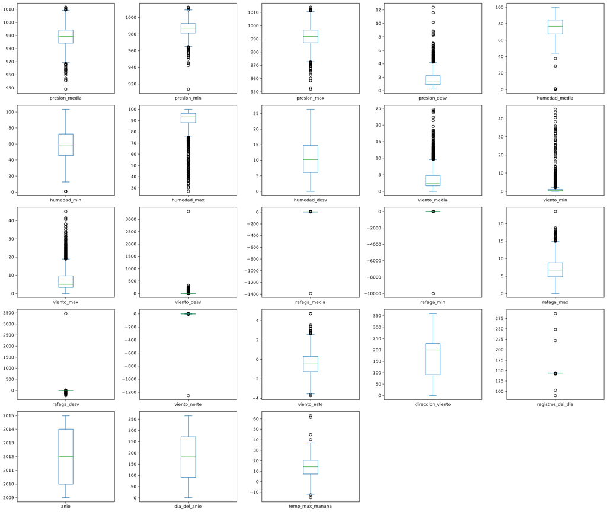

```python
import matplotlib.pyplot as plt

num_cols = data.select_dtypes(include='number').columns
data[num_cols].plot(kind='box', subplots=True, layout=(6,5), figsize=(20,20))
plt.tight_layout()
plt.show()
```

## Análisis y decisión sobre outliers

El boxplot general muestra varias columnas con puntos alejados del resto. Antes de decidir qué hacer, conviene distinguir dos tipos de "outlier":

1. **Errores de captura evidentes** — valores físicamente imposibles para la variable (ej. una ráfaga de viento negativa). Estos se eliminan, porque no representan un día real de clima extremo, sino un dato corrupto.
2. **Valores extremos pero físicamente plausibles** (ej. un día muy caliente o muy ventoso) — estos se conservan, porque son información real que el modelo debe poder aprender.

Se revisan puntualmente las variables con valores fuera de rango físico razonable.

```python
# Variables que físicamente no pueden ser negativas o tienen un tope conocido
imposibles = pd.Series(False, index=data.index)

if 'rafaga_media' in data.columns:
    cond = data['rafaga_media'] < 0
    print(f"rafaga_media < 0: {cond.sum()} fila(s)")
    imposibles |= cond

if 'viento_norte' in data.columns:
    # viento_norte/viento_este son componentes de un vector de viento; el resto
    # de la columna está en un rango de un dígito (-5 a 5 aprox.), valores de
    # tres dígitos son corrupción, no viento real.
    cond = data['viento_norte'].abs() > 100
    print(f"|viento_norte| > 100: {cond.sum()} fila(s)")
    imposibles |= cond

if 'registros_del_dia' in data.columns:
    # Estación mide cada 10 min -> máximo teórico 144 registros/día
    cond = data['registros_del_dia'] > 144
    print(f"registros_del_dia > 144: {cond.sum()} fila(s)")
    imposibles |= cond

print(f"\nTotal de filas eliminadas por outliers imposibles: {imposibles.sum()} de {data.shape[0]}")
data = data[~imposibles]
print(f"Shape final tras limpieza de outliers: {data.shape}")
```

```
rafaga_media < 0: 1 fila(s)
|viento_norte| > 100: 1 fila(s)
registros_del_dia > 144: 4 fila(s)

Total de filas eliminadas por outliers imposibles: 5 de 2405
Shape final tras limpieza de outliers: (2400, 27)
```

## Filas sin valor de la variable objetivo

`temp_max_manana` (el target) también tenía nulos (~3.7% del dataset original, visto en la revisión inicial de completitud) que nunca se trataron: solo se imputaron las *features* de `X_train`/`X_test`, nunca la variable a predecir. Esto no se puede imputar — "inventar" una etiqueta de entrenamiento introduciría información falsa que el modelo aprendería como si fuera real. La única opción correcta es eliminar esas filas, y debe hacerse **antes** del split para que ni entrenamiento ni test contengan observaciones sin etiqueta real.

```python
print(f"Filas con temp_max_manana nulo: {data['temp_max_manana'].isna().sum()} de {data.shape[0]}")
data = data.dropna(subset=['temp_max_manana'])
print(f"Shape final: {data.shape}")
```

```
Filas con temp_max_manana nulo: 89 de 2400
Shape final: (2311, 27)
```

## Correlación con la variable objetivo (`temp_max_manana`)

Uno de los objetivos del laboratorio es identificar qué variables meteorológicas aportan más a la predicción. Como primer acercamiento (antes de entrenar cualquier modelo), se mira la correlación lineal simple de cada variable numérica con el target.

```
humedad_desv         0.576054
humedad_min         -0.470152
humedad_media       -0.443738
presion_desv        -0.207449
dia_del_anio         0.170048
humedad_max         -0.155580
presion_min          0.145108
presion_media        0.120290
rafaga_media        -0.117708
anio                 0.088600
presion_max          0.071896
rafaga_min          -0.063755
viento_norte        -0.054640
rafaga_desv         -0.051253
viento_media        -0.049354
viento_desv          0.048357
viento_min          -0.043566
rafaga_max           0.028248
direccion_viento     0.023353
viento_max           0.021146
registros_del_dia   -0.007750
viento_este         -0.004304
Name: temp_max_manana, dtype: float64
```

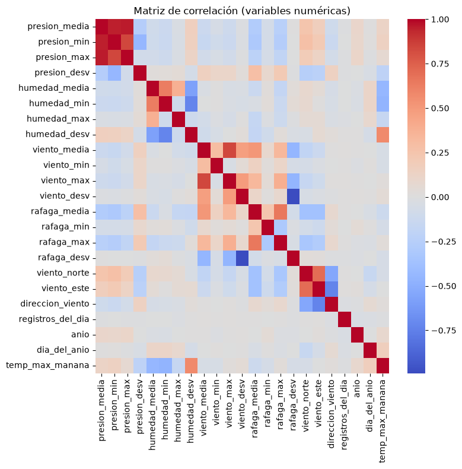

```python
num_cols_target = data.select_dtypes(include='number').columns
corr_target = data[num_cols_target].corr(numeric_only=True)['temp_max_manana'].drop('temp_max_manana').sort_values(key=abs, ascending=False)
print(corr_target)

plt.figure(figsize=(8, 8))
sns.heatmap(data[num_cols_target].corr(numeric_only=True), cmap='coolwarm', center=0, annot=False)
plt.title('Matriz de correlación (variables numéricas)')
plt.tight_layout()
plt.show()
```

## Separación entrenamiento / prueba

Siguiendo lo indicado en el enunciado, se separa un 25% para test con `random_state=42`. Esto se hace **ahora**, sobre los datos ya limpios (categorías normalizadas, magnitudes corregidas, duplicados resueltos, outliers imposibles eliminados) pero **antes de imputar** los valores faltantes restantes, precisamente para evitar la fuga de datos mencionada antes: cualquier estadístico (mediana, moda) que se use para imputar debe calcularse únicamente con el conjunto de entrenamiento.

```python
from sklearn.model_selection import train_test_split

X = data.drop(columns=['temp_max_manana'])
y = data['temp_max_manana']

X_train, X_test, y_train, y_test = train_test_split(
    X, y, test_size=0.25, random_state=42
)

print(f"X_train: {X_train.shape} | X_test: {X_test.shape}")
```

```
X_train: (1733, 26) | X_test: (578, 26)
```

## Imputación de valores faltantes (después del split, sin fuga de datos)

Se ajusta el imputador **solo con `X_train`** y se aplica esa misma transformación a `X_train` y `X_test`. Así, ningún valor usado para llenar huecos proviene de filas que el modelo no debería haber visto todavía.

> Esta es la versión "manual" de la preparación, útil para seguir explorando los datos ya completos. Cuando se construyan los modelos (siguiente etapa: **Construcción de modelo**), estos mismos pasos —imputación, y lo que se agregue de codificación de categóricas o escalado— se deben encapsular en un `Pipeline`/`ColumnTransformer` de scikit-learn, tal como pide el enunciado, para que el ajuste quede automáticamente ligado a `fit()` sobre el conjunto de entrenamiento.

```python
num_cols = X_train.select_dtypes(include=np.number).columns
cat_cols = X_train.select_dtypes(include='object').columns

print("Nulos en X_train antes de imputar:")
print(X_train.isna().sum().loc[lambda s: s > 0])

num_imputer = SimpleImputer(strategy='median').fit(X_train[num_cols])
cat_imputer = SimpleImputer(strategy='most_frequent').fit(X_train[cat_cols])

X_train = X_train.copy()
X_test = X_test.copy()

X_train[num_cols] = num_imputer.transform(X_train[num_cols])
X_train[cat_cols] = cat_imputer.transform(X_train[cat_cols])

X_test[num_cols] = num_imputer.transform(X_test[num_cols])
X_test[cat_cols] = cat_imputer.transform(X_test[cat_cols])

print("\nNulos en X_train después de imputar:", X_train.isna().sum().sum())
print("Nulos en X_test después de imputar:", X_test.isna().sum().sum())
```

```
Nulos en X_train antes de imputar:
presion_media         50
presion_min           53
presion_max           46
presion_desv          64
humedad_media         52
humedad_min           46
humedad_max           56
humedad_desv          45
viento_media          63
viento_min            67
viento_max            57
viento_desv           48
rafaga_media          52
rafaga_min            46
rafaga_max            49
rafaga_desv           51
viento_norte          46
viento_este           40
direccion_viento      55
registros_del_dia     55
dia_del_anio          41
estacion_anio        169
mes                   56
sector_viento         52
dtype: int64

Nulos en X_train después de imputar: 0
Nulos en X_test después de imputar: 0
```

# Construcción de modelos de regresión lineal

El enunciado pide **dos** modelos con estrategias de preparación distintas, comparados con RMSE/MAE/R². Vamos a construir **tres** (para tener más margen de comparación), en orden creciente de complejidad y, en principio, de desempeño:

- **Modelo 1 — Básico:** solo variables numéricas, sin ingeniería de características. Sirve como línea base: si los modelos 2 y 3 no superan esto, algo está mal en cómo se está usando la información adicional.
- **Modelo 2:** incorpora las variables categóricas (`mes`, `estacion_anio`, `sector_viento`) mediante codificación.
- **Modelo 3:** además de lo anterior, agrega ingeniería de características (por ejemplo, codificación cíclica de variables temporales) para capturar mejor los patrones estacionales sin salirse de un modelo **lineal** (no se permiten modelos polinomiales).

Cada modelo se entrena con su propio `Pipeline` de scikit-learn — así el preprocesamiento específico de cada estrategia queda ligado al modelo y se puede aplicar de forma consistente tanto a test como, más adelante, al archivo de predicción final sin volver a escribir el código de limpieza.

## Modelo 1 — Regresión lineal básica (solo variables numéricas)

**Estrategia de preparación:** usar únicamente las columnas numéricas ya limpias (`X_train`/`X_test`), con imputación de mediana (por robustez, aunque ya no debería haber nulos tras la preparación previa) y escalado estándar. Se descartan por completo `fecha` (no es una variable predictiva, es un identificador temporal) y las tres columnas categóricas (`mes`, `estacion_anio`, `sector_viento`) — precisamente porque la idea de este modelo es ser la versión más simple posible: sin codificación de categóricas, sin características nuevas, sin interacciones. Esto da un punto de referencia claro contra el cual medir si el trabajo adicional de los modelos 2 y 3 realmente aporta.

```python
# Columnas numéricas a usar (todo lo numérico excepto el target, que ya no está en X)
numeric_features_m1 = X_train.select_dtypes(include=np.number).columns.tolist()
print(f"Variables numéricas usadas en Modelo 1 ({len(numeric_features_m1)}):")
print(numeric_features_m1)
```

[output not shown]

```python
# Preprocesamiento: imputar (por robustez) + escalar. Sin transformador categórico:
# ninguna columna categórica se incluye en el ColumnTransformer, así que
# quedan excluidas automáticamente del modelo (remainder='drop' por defecto).
numeric_transformer_m1 = Pipeline(steps=[
    ("imputer", SimpleImputer(strategy="median")),
    ("scaler", StandardScaler()),
])

preprocessor_m1 = ColumnTransformer(transformers=[
    ("num", numeric_transformer_m1, numeric_features_m1),
])

pipeline_modelo1 = Pipeline(steps=[
    ("preprocesamiento", preprocessor_m1),
    ("regresor", LinearRegression()),
])

pipeline_modelo1
```

```
Pipeline(steps=[('preprocesamiento',
                 ColumnTransformer(transformers=[('num',
                                                  Pipeline(steps=[('imputer',
                                                                   SimpleImputer(strategy='median')),
                                                                  ('scaler',
                                                                   StandardScaler())]),
                                                  ['presion_media',
                                                   'presion_min', 'presion_max',
                                                   'presion_desv',
                                                   'humedad_media',
                                                   'humedad_min', 'humedad_max',
                                                   'humedad_desv',
                                                   'viento_media', 'viento_min',
                                                   'viento_max', 'viento_desv',
                                                   'rafaga_media', 'rafaga_min',
                                                   'rafaga_max', 'rafaga_desv',
                                                   'viento_norte',
                                                   'viento_este',
                                                   'direccion_viento',
                                                   'registros_del_dia', 'anio',
                                                   'dia_del_anio'])])),
                ('regresor', LinearRegression())])
```

```python
# El pipeline completo (preprocesamiento + regresión) se ajusta con fit()
# sobre datos de entrenamiento crudos (aún con columnas categóricas y fecha):
# el propio pipeline se encarga de seleccionar y transformar solo lo que necesita.
pipeline_modelo1.fit(X_train, y_train)
```

```
Pipeline(steps=[('preprocesamiento',
                 ColumnTransformer(transformers=[('num',
                                                  Pipeline(steps=[('imputer',
                                                                   SimpleImputer(strategy='median')),
                                                                  ('scaler',
                                                                   StandardScaler())]),
                                                  ['presion_media',
                                                   'presion_min', 'presion_max',
                                                   'presion_desv',
                                                   'humedad_media',
                                                   'humedad_min', 'humedad_max',
                                                   'humedad_desv',
                                                   'viento_media', 'viento_min',
                                                   'viento_max', 'viento_desv',
                                                   'rafaga_media', 'rafaga_min',
                                                   'rafaga_max', 'rafaga_desv',
                                                   'viento_norte',
                                                   'viento_este',
                                                   'direccion_viento',
                                                   'registros_del_dia', 'anio',
                                                   'dia_del_anio'])])),
                ('regresor', LinearRegression())])
```

### Evaluación del Modelo 1

Se calculan RMSE, MAE y R² tanto en train como en test. Comparar ambos conjuntos es importante: si el desempeño en train es mucho mejor que en test, es señal de sobreajuste; si son similares (como se espera de un modelo tan simple y lineal), el modelo generaliza pero probablemente le falta información para capturar mejor la variabilidad de la temperatura — que es justo el rol de este modelo como línea base.

```python
# Función reutilizable: se usará también para los modelos 2 y 3, así queda
# lista la tabla comparativa (RMSE/MAE/R² en train y test) que pide el enunciado.
resultados_modelos = []

def evaluar_modelo(nombre, pipeline, X_train, y_train, X_test, y_test, guardar=True):
    y_train_pred = pipeline.predict(X_train)
    y_test_pred = pipeline.predict(X_test)

    metricas = {
        "modelo": nombre,
        "RMSE_train": np.sqrt(mean_squared_error(y_train, y_train_pred)),
        "MAE_train": mean_absolute_error(y_train, y_train_pred),
        "R2_train": r2_score(y_train, y_train_pred),
        "RMSE_test": np.sqrt(mean_squared_error(y_test, y_test_pred)),
        "MAE_test": mean_absolute_error(y_test, y_test_pred),
        "R2_test": r2_score(y_test, y_test_pred),
    }
    if guardar:
        resultados_modelos.append(metricas)
    return metricas

metricas_modelo1 = evaluar_modelo("Modelo 1 - Básico (solo numéricas)", pipeline_modelo1, X_train, y_train, X_test, y_test)
pd.DataFrame([metricas_modelo1]).set_index("modelo")
```

| modelo | RMSE_train | MAE_train | R2_train | RMSE_test | MAE_test | R2_test |
| --- | --- | --- | --- | --- | --- | --- |
| Modelo 1 - Básico (solo numéricas) | 6.834712 | 5.332623 | 0.4495 | 6.775563 | 5.250133 | 0.410842 |

## Modelo 2 — Regresión lineal con variables categóricas

**Idea central:** `LinearRegression` solo entiende números. Las columnas `mes`, `estacion_anio` y `sector_viento` son texto (categorías *nominales*: no tienen un orden natural — "enero" no es "menor" que "diciembre"). Para usarlas en un modelo lineal hay que convertirlas a números de una forma que **no invente un orden que no existe**.

**¿Por qué no simplemente numerarlas (enero=1, febrero=2, ...)?** Porque eso le diría al modelo que diciembre (12) está "3 veces más lejos" de marzo (3) que febrero (2), una relación numérica arbitraria que no tiene ningún significado físico. El modelo interpretaría esa distancia como si fuera información real.

**Solución: One-Hot Encoding (OHE).** Cada categoría se convierte en una columna binaria (0/1) que indica "¿es esta la categoría?". Por ejemplo, `mes` se convierte en 12 columnas (`mes_enero`, `mes_febrero`, ...), cada fila tiene un 1 en la columna de su mes y 0 en las demás. Así el modelo puede asignarle un coeficiente propio a cada categoría, sin asumir ningún orden ni distancia entre ellas.

**Detalle técnico importante — `drop='first'`:** Si generamos una columna binaria por *cada* categoría (12 para `mes`) y el modelo también tiene un intercepto, las columnas quedan perfectamente correlacionadas entre sí (siempre suman 1 entre todas) — esto se llama la **"trampa de las variables dummy"** (*dummy variable trap*). `LinearRegression` no truena por esto (matemáticamente sigue resolviendo el sistema), pero los coeficientes individuales dejan de ser interpretables de forma única. La solución estándar es **omitir una categoría de referencia** (`drop='first'`): si `mes_enero` es la categoría base, el coeficiente de `mes_febrero` se interpreta como "cuánto cambia la predicción respecto a un día de enero, manteniendo todo lo demás igual".

**`handle_unknown='ignore'`:** por seguridad, si en `X_test` apareciera una categoría que `OneHotEncoder` nunca vio en `X_train` (no debería pasar aquí porque ya normalizamos e imputamos antes del split, pero es buena práctica dejarlo), en vez de fallar, esa fila simplemente queda con todas las columnas de esa variable en 0.

**Arquitectura del pipeline:** igual que en el Modelo 1, pero el `ColumnTransformer` ahora tiene **dos** ramas que corren en paralelo y se concatenan al final:

- rama `num`: las mismas columnas numéricas del Modelo 1 → imputar (mediana) + escalar.
- rama `cat`: `mes`, `estacion_anio`, `sector_viento` → imputar (moda) + One-Hot Encoding.

```python
# Mismas variables numéricas que en el Modelo 1
numeric_features_m2 = X_train.select_dtypes(include=np.number).columns.tolist()

# Variables categóricas que se incorporan en este modelo
categorical_features_m2 = ['mes', 'estacion_anio', 'sector_viento']

print(f"Variables numéricas ({len(numeric_features_m2)}): {numeric_features_m2}")
print(f"\nVariables categóricas ({len(categorical_features_m2)}): {categorical_features_m2}")
```

```
Variables numéricas (22): ['presion_media', 'presion_min', 'presion_max', 'presion_desv', 'humedad_media', 'humedad_min', 'humedad_max', 'humedad_desv', 'viento_media', 'viento_min', 'viento_max', 'viento_desv', 'rafaga_media', 'rafaga_min', 'rafaga_max', 'rafaga_desv', 'viento_norte', 'viento_este'…

Variables categóricas (3): ['mes', 'estacion_anio', 'sector_viento']
```

```python
# Rama numérica: idéntica a la del Modelo 1 (imputar mediana + escalar)
numeric_transformer_m2 = Pipeline(steps=[
    ("imputer", SimpleImputer(strategy="median")),
    ("scaler", StandardScaler()),
])

# Rama categórica: imputar por la moda + One-Hot Encoding
# drop='first' evita la trampa de las variables dummy (ver explicación arriba)
# handle_unknown='ignore' evita errores si aparece una categoría no vista en train
categorical_transformer_m2 = Pipeline(steps=[
    ("imputer", SimpleImputer(strategy="most_frequent")),
    ("onehot", OneHotEncoder(drop="first", handle_unknown="ignore")),
])

# El ColumnTransformer aplica cada rama a sus columnas y concatena el resultado
preprocessor_m2 = ColumnTransformer(transformers=[
    ("num", numeric_transformer_m2, numeric_features_m2),
    ("cat", categorical_transformer_m2, categorical_features_m2),
])

pipeline_modelo2 = Pipeline(steps=[
    ("preprocesamiento", preprocessor_m2),
    ("regresor", LinearRegression()),
])

pipeline_modelo2
```

```
Pipeline(steps=[('preprocesamiento',
                 ColumnTransformer(transformers=[('num',
                                                  Pipeline(steps=[('imputer',
                                                                   SimpleImputer(strategy='median')),
                                                                  ('scaler',
                                                                   StandardScaler())]),
                                                  ['presion_media',
                                                   'presion_min', 'presion_max',
                                                   'presion_desv',
                                                   'humedad_media',
                                                   'humedad_min', 'humedad_max',
                                                   'humedad_desv',
                                                   'viento_media', 'viento_min',
                                                   'viento_max', 'viento_desv',
                                                   'rafaga_me..., 'rafaga_min',
                                                   'rafaga_max', 'rafaga_desv',
                                                   'viento_norte',
                                                   'viento_este',
                                                   'direccion_viento',
                                                   'registros_del_dia', 'anio',
                                                   'dia_del_anio']),
                                                 ('cat',
                                                  Pipeline(steps=[('imputer',
                                                                   SimpleImputer(strategy='most_frequent')),
                                                                  ('onehot',
                                                                   OneHotEncoder(drop='first',
                                                                                 handle_unknown='ignore'))]),
                                                  ['mes', 'estacion_anio',
                                                   'sector_viento'])])),
                ('regresor', LinearRegression())])
```

```python
# Igual que en el Modelo 1: fit() se llama sobre X_train "crudo" (con las columnas
# categóricas y fecha incluidas); el ColumnTransformer se encarga de seleccionar
# y transformar solo lo que cada rama necesita.
pipeline_modelo2.fit(X_train, y_train)
```

```
Pipeline(steps=[('preprocesamiento',
                 ColumnTransformer(transformers=[('num',
                                                  Pipeline(steps=[('imputer',
                                                                   SimpleImputer(strategy='median')),
                                                                  ('scaler',
                                                                   StandardScaler())]),
                                                  ['presion_media',
                                                   'presion_min', 'presion_max',
                                                   'presion_desv',
                                                   'humedad_media',
                                                   'humedad_min', 'humedad_max',
                                                   'humedad_desv',
                                                   'viento_media', 'viento_min',
                                                   'viento_max', 'viento_desv',
                                                   'rafaga_me..., 'rafaga_min',
                                                   'rafaga_max', 'rafaga_desv',
                                                   'viento_norte',
                                                   'viento_este',
                                                   'direccion_viento',
                                                   'registros_del_dia', 'anio',
                                                   'dia_del_anio']),
                                                 ('cat',
                                                  Pipeline(steps=[('imputer',
                                                                   SimpleImputer(strategy='most_frequent')),
                                                                  ('onehot',
                                                                   OneHotEncoder(drop='first',
                                                                                 handle_unknown='ignore'))]),
                                                  ['mes', 'estacion_anio',
                                                   'sector_viento'])])),
                ('regresor', LinearRegression())])
```

### Evaluación del Modelo 2

Se reutiliza la función `evaluar_modelo` definida para el Modelo 1 (por eso quedó guardada como reutilizable) y se guarda el resultado en `resultados_modelos`, junto al del Modelo 1, para ir armando la tabla comparativa.

```python
metricas_modelo2 = evaluar_modelo(
    "Modelo 2 - + categóricas (OHE)", pipeline_modelo2, X_train, y_train, X_test, y_test
)

pd.DataFrame(resultados_modelos).set_index("modelo")
```

| modelo | RMSE_train | MAE_train | R2_train | RMSE_test | MAE_test | R2_test |
| --- | --- | --- | --- | --- | --- | --- |
| Modelo 1 - Básico (solo numéricas) | 6.834712 | 5.332623 | 0.449500 | 6.775563 | 5.250133 | 0.410842 |
| Modelo 2 - + categóricas (OHE) | 6.511044 | 5.048965 | 0.500404 | 6.661687 | 5.125108 | 0.430480 |

## Modelo 3 — Regresión lineal con ingeniería de características (codificación cíclica)

**El problema que resuelve este modelo:** hay dos variables numéricas en el dataset que en realidad son **circulares**, no lineales:

- **`dia_del_anio`** (1 a 366): el día 365 (31 de diciembre) y el día 1 (1 de enero) son *consecutivos* en la realidad (un día de diferencia), pero numéricamente están a 364 unidades de distancia. Un modelo lineal, tal como se usó en los Modelos 1 y 2, no tiene forma de saber esto — para él, 365 y 1 son valores tan distintos como 365 y 100.
- **`direccion_viento`** (0° a 360°, dirección del viento en grados): el mismo problema. Viento a 359° y viento a 1° son prácticamente la misma dirección (un giro de 2°), pero numéricamente están casi todo lo lejos que se puede estar en esa escala.

Esto le hace perder al modelo la información de la **estacionalidad** (los patrones de temperatura que se repiten cada año) y de la continuidad de la dirección del viento.

**La solución: codificación cíclica con seno y coseno.** En vez de usar el valor original, se representa la variable como un punto en un círculo unitario:

$$x_{sin} = \sin\left(\dfrac{2\pi \cdot x}{periodo}\right) \qquad x_{cos} = \cos\left(\dfrac{2\pi \cdot x}{periodo}\right)$$

Con `periodo = 365.25` para `dia_del_anio` y `periodo = 360` para `direccion_viento`. Cada valor original se convierte en **dos** columnas nuevas. La clave es que ahora la distancia euclidiana entre los puntos (sin, cos) sí refleja la distancia real en el círculo: el punto del día 365 queda geométricamente junto al punto del día 1, y el viento a 359° queda junto al de 1°. Esto sigue siendo una transformación de las variables de entrada — el modelo resultante sigue siendo una regresión **lineal** sobre las nuevas columnas (`sin`, `cos`), no un modelo polinomial.

**Cómo se implementa dentro de un `Pipeline` de scikit-learn:** no existe un transformador para esto en scikit-learn, así que se define una función propia y se envuelve en un `FunctionTransformer`. Se le indica explícitamente cómo se llaman las columnas que produce (`feature_names_out`) para que más adelante se puedan seguir usando nombres de variable legibles al analizar los coeficientes del modelo (uno de los objetivos del laboratorio).

**Resto de la estrategia:** se mantiene todo lo del Modelo 2 (numéricas escaladas + categóricas con One-Hot Encoding) — `dia_del_anio` y `direccion_viento` simplemente se sacan de la rama numérica normal y pasan a su propia rama cíclica.

```python
from sklearn.preprocessing import FunctionTransformer
from functools import partial


def cyclical_encode(X, period):
    """Convierte una columna (n_filas, 1) en dos columnas [sin, cos]."""
    valores = np.asarray(X, dtype=float).reshape(-1, 1)
    angulo = 2 * np.pi * valores / period
    return np.hstack([np.sin(angulo), np.cos(angulo)])


def cyclical_feature_names(transformer, input_features):
    """Nombra las columnas de salida como <variable>_sin y <variable>_cos."""
    base = input_features[0]
    return np.array([f"{base}_sin", f"{base}_cos"])


def make_cyclical_transformer(period):
    return FunctionTransformer(
        func=partial(cyclical_encode, period=period),
        feature_names_out=cyclical_feature_names,
    )


print("cyclical_encode / make_cyclical_transformer definidos")
```

```
cyclical_encode / make_cyclical_transformer definidos
```

```python
# Las variables cíclicas salen de la lista de "numéricas normales" y tienen su propia rama
columnas_ciclicas = ["dia_del_anio", "direccion_viento"]
numeric_features_m3 = [c for c in numeric_features_m2 if c not in columnas_ciclicas]

print(f"Variables numéricas 'normales' en Modelo 3 ({len(numeric_features_m3)})")
print(f"Variables cíclicas: {columnas_ciclicas}")
print(f"Variables categóricas (igual que Modelo 2): {categorical_features_m2}")

# Rama numérica "normal": igual que en los modelos anteriores
numeric_transformer_m3 = Pipeline(steps=[
    ("imputer", SimpleImputer(strategy="median")),
    ("scaler", StandardScaler()),
])

# Rama cíclica: imputar (por si acaso) + transformar a [sin, cos]
# dia_del_anio: periodo de un año (365.25 para promediar años bisiestos)
dia_anio_transformer = Pipeline(steps=[
    ("imputer", SimpleImputer(strategy="median")),
    ("ciclico", make_cyclical_transformer(period=365.25)),
])

# direccion_viento: periodo de una vuelta completa (360 grados)
direccion_transformer = Pipeline(steps=[
    ("imputer", SimpleImputer(strategy="median")),
    ("ciclico", make_cyclical_transformer(period=360)),
])

# Rama categórica: igual que en el Modelo 2
categorical_transformer_m3 = Pipeline(steps=[
    ("imputer", SimpleImputer(strategy="most_frequent")),
    ("onehot", OneHotEncoder(drop="first", handle_unknown="ignore")),
])

preprocessor_m3 = ColumnTransformer(transformers=[
    ("num", numeric_transformer_m3, numeric_features_m3),
    ("dia_anio_ciclico", dia_anio_transformer, ["dia_del_anio"]),
    ("direccion_ciclica", direccion_transformer, ["direccion_viento"]),
    ("cat", categorical_transformer_m3, categorical_features_m2),
])

pipeline_modelo3 = Pipeline(steps=[
    ("preprocesamiento", preprocessor_m3),
    ("regresor", LinearRegression()),
])

pipeline_modelo3
```

```
Variables numéricas 'normales' en Modelo 3 (20)
Variables cíclicas: ['dia_del_anio', 'direccion_viento']
Variables categóricas (igual que Modelo 2): ['mes', 'estacion_anio', 'sector_viento']
```

```
Pipeline(steps=[('preprocesamiento',
                 ColumnTransformer(transformers=[('num',
                                                  Pipeline(steps=[('imputer',
                                                                   SimpleImputer(strategy='median')),
                                                                  ('scaler',
                                                                   StandardScaler())]),
                                                  ['presion_media',
                                                   'presion_min', 'presion_max',
                                                   'presion_desv',
                                                   'humedad_media',
                                                   'humedad_min', 'humedad_max',
                                                   'humedad_desv',
                                                   'viento_media', 'viento_min',
                                                   'viento_max', 'viento_desv',
                                                   'rafaga_me...
                                                                   FunctionTransformer(feature_names_out=<function cyclical_feature_names at 0x15a2676a0>,
                                                                                       func=functools.partial(<function cyclical_encode at 0x15a267380>, period=360)))]),
                                                  ['direccion_viento']),
                                                 ('cat',
                                                  Pipeline(steps=[('imputer',
                                                                   SimpleImputer(strategy='most_frequent')),
                                                                  ('onehot',
                                                                   OneHotEncoder(drop='first',
                                                                                 handle_unknown='ignore'))]),
                                                  ['mes', 'estacion_anio',
                                                   'sector_viento'])])),
                ('regresor', LinearRegression())])
```

```python
pipeline_modelo3.fit(X_train, y_train)
```

```
Pipeline(steps=[('preprocesamiento',
                 ColumnTransformer(transformers=[('num',
                                                  Pipeline(steps=[('imputer',
                                                                   SimpleImputer(strategy='median')),
                                                                  ('scaler',
                                                                   StandardScaler())]),
                                                  ['presion_media',
                                                   'presion_min', 'presion_max',
                                                   'presion_desv',
                                                   'humedad_media',
                                                   'humedad_min', 'humedad_max',
                                                   'humedad_desv',
                                                   'viento_media', 'viento_min',
                                                   'viento_max', 'viento_desv',
                                                   'rafaga_me...
                                                                   FunctionTransformer(feature_names_out=<function cyclical_feature_names at 0x15a2676a0>,
                                                                                       func=functools.partial(<function cyclical_encode at 0x15a267380>, period=360)))]),
                                                  ['direccion_viento']),
                                                 ('cat',
                                                  Pipeline(steps=[('imputer',
                                                                   SimpleImputer(strategy='most_frequent')),
                                                                  ('onehot',
                                                                   OneHotEncoder(drop='first',
                                                                                 handle_unknown='ignore'))]),
                                                  ['mes', 'estacion_anio',
                                                   'sector_viento'])])),
                ('regresor', LinearRegression())])
```

### Evaluación del Modelo 3 y tabla comparativa final

Se agrega el resultado a `resultados_modelos` para comparar los tres modelos juntos.

```python
metricas_modelo3 = evaluar_modelo(
    "Modelo 3 - + codificación cíclica", pipeline_modelo3, X_train, y_train, X_test, y_test
)

tabla_comparativa = pd.DataFrame(resultados_modelos).set_index("modelo")
tabla_comparativa
```

| modelo | RMSE_train | MAE_train | R2_train | RMSE_test | MAE_test | R2_test |
| --- | --- | --- | --- | --- | --- | --- |
| Modelo 1 - Básico (solo numéricas) | 6.834712 | 5.332623 | 0.449500 | 6.775563 | 5.250133 | 0.410842 |
| Modelo 2 - + categóricas (OHE) | 6.511044 | 5.048965 | 0.500404 | 6.661687 | 5.125108 | 0.430480 |
| Modelo 3 - + codificación cíclica | 4.834598 | 3.546722 | 0.724553 | 5.210319 | 3.719824 | 0.651607 |

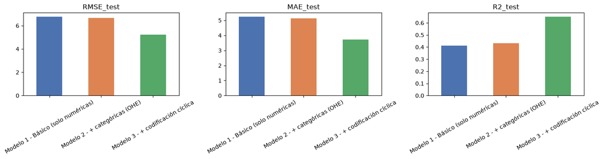

```python
# Comparación visual de RMSE/MAE/R² (test) entre los tres modelos
fig, axes = plt.subplots(1, 3, figsize=(15, 4))

for ax, metrica in zip(axes, ["RMSE_test", "MAE_test", "R2_test"]):
    tabla_comparativa[metrica].plot(kind="bar", ax=ax, color=["#4c72b0", "#dd8452", "#55a868"])
    ax.set_title(metrica)
    ax.set_xlabel("")
    ax.tick_params(axis="x", rotation=30)

plt.tight_layout()
plt.show()
```

## Variables más importantes

Con `LinearRegression`, la forma directa de ver "qué tanto aporta cada variable" es mirar sus **coeficientes**: cada uno dice cuánto cambia la predicción de `temp_max_manana` cuando esa variable cambia, manteniendo las demás fijas.

**Por qué hay que tener cuidado al comparar coeficientes entre sí:**

- Las variables numéricas (rama `num`) pasaron por `StandardScaler`, así que están en la misma escala (media 0, desviación estándar 1). Sus coeficientes **sí son comparables entre ellos**: representan el efecto de moverse 1 desviación estándar en esa variable.
- Las columnas de One-Hot Encoding (`mes_*`, `sector_viento_*`, etc.) son binarias (0/1), no están escaladas. Su coeficiente representa el efecto de "ser esa categoría" comparado con la categoría de referencia (la que se dejó fuera con `drop='first'`) — **no** es directamente comparable en magnitud con el de una variable numérica estandarizada.
- Lo mismo aplica a las columnas `_sin`/`_cos` de la codificación cíclica: hay que interpretarlas juntas (como par), no una por separado.

Para obtener los nombres de cada columna generada por el `ColumnTransformer` (incluyendo las del One-Hot Encoding y las cíclicas) se usa `get_feature_names_out()`, que junta los nombres que cada rama del pipeline reporta — por eso se definió `feature_names_out` explícitamente en el transformador cíclico.

```
                          variable  coeficiente
dia_anio_ciclico__dia_del_anio_cos    -8.217768
dia_anio_ciclico__dia_del_anio_sin    -3.481007
             cat__sector_viento_NO    -3.388647
             cat__sector_viento_SE    -2.651787
              cat__sector_viento_N    -2.492067
              cat__sector_viento_O    -2.361118
             cat__sector_viento_SO    -2.113483
                 num__viento_norte    -1.701970
             cat__sector_viento_NE    -1.636570
              cat__sector_viento_S    -1.428567
      cat__estacion_anio_primavera     1.367801
                cat__mes_diciembre    -1.216902
                 num__humedad_desv     1.097896
                  cat__mes_febrero    -1.031276
                num__presion_media     0.992162
```

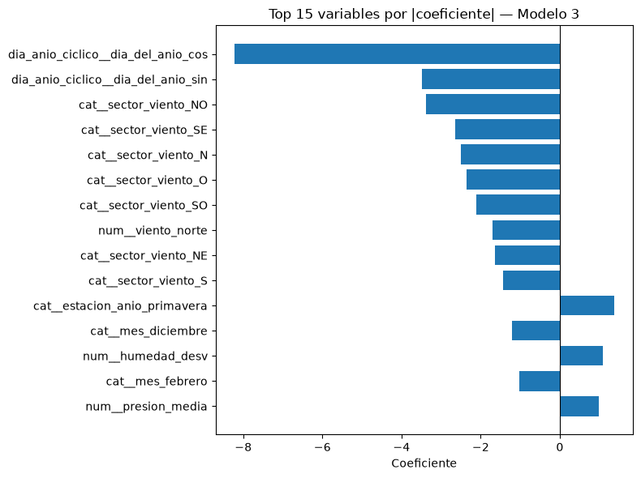

```python
nombres_variables_m3 = pipeline_modelo3.named_steps["preprocesamiento"].get_feature_names_out()
coeficientes_m3 = pipeline_modelo3.named_steps["regresor"].coef_

coef_df = pd.DataFrame({
    "variable": nombres_variables_m3,
    "coeficiente": coeficientes_m3,
})
coef_df["coef_abs"] = coef_df["coeficiente"].abs()
coef_df = coef_df.sort_values("coef_abs", ascending=False).reset_index(drop=True)

top_15 = coef_df.head(15)
print(top_15.drop(columns="coef_abs").to_string(index=False))

plt.figure(figsize=(8, 6))
plt.barh(top_15["variable"][::-1], top_15["coeficiente"][::-1])
plt.axvline(0, color="black", linewidth=0.8)
plt.title("Top 15 variables por |coeficiente| — Modelo 3")
plt.xlabel("Coeficiente")
plt.tight_layout()
plt.show()
```

## Predicciones sobre datos de prueba

Como cierre, se usa el mejor modelo de los tres (el de mayor R² / menor RMSE en test, según `tabla_comparativa`) para generar predicciones sobre `X_test` y comparar visualmente contra los valores reales. El gráfico de dispersión "real vs. predicho" es una forma estándar de inspeccionar qué tan bien ajusta el modelo: si las predicciones fueran perfectas, todos los puntos caerían sobre la línea diagonal `y = x`.

```python
# Selección automática del mejor modelo según RMSE en test
pipelines = {
    "Modelo 1 - Básico (solo numéricas)": pipeline_modelo1,
    "Modelo 2 - + categóricas (OHE)": pipeline_modelo2,
    "Modelo 3 - + codificación cíclica": pipeline_modelo3,
}

mejor_nombre = tabla_comparativa["RMSE_test"].idxmin()
mejor_pipeline = pipelines[mejor_nombre]
print(f"Mejor modelo según RMSE_test: {mejor_nombre}")

y_test_pred = mejor_pipeline.predict(X_test)

predicciones_df = pd.DataFrame({
    "real": y_test.values,
    "prediccion": y_test_pred,
})
predicciones_df["error_abs"] = (predicciones_df["real"] - predicciones_df["prediccion"]).abs()

predicciones_df.head(10)
```

```
Mejor modelo según RMSE_test: Modelo 3 - + codificación cíclica
```

|  | real | prediccion | error_abs |
| --- | --- | --- | --- |
| 0 | 13.57 | 7.967165 | 5.602835 |
| 1 | 26.42 | 24.971396 | 1.448604 |
| 2 | 25.57 | 21.266137 | 4.303863 |
| 3 | 2.06 | 0.807585 | 1.252415 |
| 4 | 6.13 | 5.683211 | 0.446789 |
| 5 | 12.04 | 11.089073 | 0.950927 |
| 6 | 6.42 | 2.559276 | 3.860724 |
| 7 | 15.75 | 20.207267 | 4.457267 |
| 8 | 5.97 | 10.298952 | 4.328952 |
| 9 | 11.46 | 11.945709 | 0.485709 |

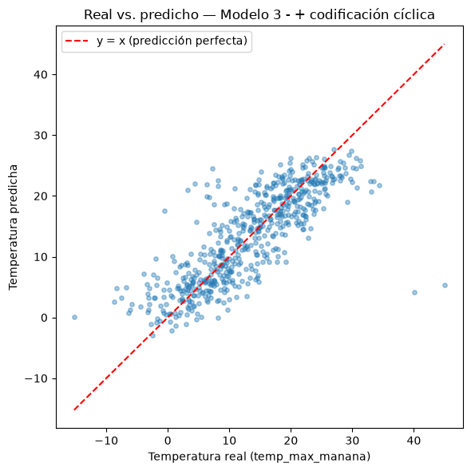

```python
plt.figure(figsize=(6, 6))
plt.scatter(predicciones_df["real"], predicciones_df["prediccion"], alpha=0.4, s=15)

lims = [predicciones_df[["real", "prediccion"]].min().min(),
        predicciones_df[["real", "prediccion"]].max().max()]
plt.plot(lims, lims, color="red", linestyle="--", label="y = x (predicción perfecta)")

plt.xlabel("Temperatura real (temp_max_manana)")
plt.ylabel("Temperatura predicha")
plt.title(f"Real vs. predicho — {mejor_nombre}")
plt.legend()
plt.tight_layout()
plt.show()
```

# Uso de IAG

**Herramienta usada:** Claude (Anthropic), vía Claude Code, con acceso directo al repositorio del laboratorio (lectura/edición de archivos, ejecución del notebook en el entorno local).

**Metodología de uso:** cada intervención relevante se registró cronológicamente en `LOG_IAG.md`, en la raíz del repositorio, con el prompt (resumido), lo que la IA encontró o generó, la justificación técnica de cada decisión, y qué fue criterio propio del equipo frente a lo sugerido por la IA. Esta sección resume ese registro y lo completa con las etapas de construcción de los Modelos 2 y 3, la evaluación comparativa final y las predicciones, realizadas después del último corte del log. Ningún hallazgo, número o corrección atribuida a la IA se aceptó sin verificarlo contra los datos reales o contra la salida efectiva de `scikit-learn`; esa verificación se detalla en cada subsección.

## Diagnóstico inicial y detección temprana de fuga de datos

**Qué se pidió:** escanear el notebook y el repositorio para identificar en qué punto estaba el laboratorio respecto al enunciado y la rúbrica, y qué faltaba.

**Qué encontró la IA:** que solo la exploración inicial (nulos, duplicados) estaba hecha (~20% del trabajo), y una advertencia temprana de **fuga de datos (data leakage)**: la imputación de nulos se estaba aplicando sobre el 100% del dataset *antes* del split train/test, lo que contamina el conjunto de test con estadísticos (mediana/moda) calculados incluyendo esas mismas filas.

**Decisión del equipo:** se confirmó el diagnóstico y se priorizó corregir la fuga de datos antes de continuar con exploración adicional — de nada serviría seguir explorando sobre un flujo que, al final, invalidaría la evaluación del modelo.

## Corrección de errores de calidad de datos

**Qué se pidió:** ayuda para corregir los errores detectados y continuar con la exploración.

**Qué encontró la IA (verificado contra los datos reales, no asumido):**

- `mes`: 60 valores únicos para 12 meses reales, con mezcla de mayúsculas/minúsculas e idioma.
- `estacion_anio`: 28 valores para 4 estaciones, incluyendo errores de tipeo y valores inválidos que no son estaciones (`'East'`, `'Estacion_Desconocida'`, `'VERANO_INVIERNO'`).
- `sector_viento`: 31 valores para 8 direcciones cardinales, mismo problema de formato.
- `presion_media`: 6 filas con error de escala ×10 (ej. `9928.77` en vez de `992.877`).
- `humedad_media` y `humedad_min`: 755 y 605 filas (~30% y 24% del dataset) almacenadas como fracción (0-1) en vez de porcentaje (0-100) — un patrón sistemático, no casos aislados.
- Un **bug propio en el código** de manejo de fechas duplicadas: una celda de agregación usaba `.mean(numeric_only=True)`, que descartaba silenciosamente las columnas categóricas, dejándolas en `NaN` para esas fechas.
- Un outlier de captura evidente: `rafaga_media = -1386.27` (una ráfaga de viento no puede ser negativa), más un valor extremo de `viento_norte` y 4 filas con `registros_del_dia > 144` (máximo teórico de la estación).

**Verificación aplicada:** el notebook se ejecutó completo de punta a punta tras cada tanda de cambios, revisando explícitamente los conteos antes/después de cada corrección.

**Qué se dejó sin resolver a propósito:** tras la corrección ×100, quedaron 26 filas con `humedad_media` ≤ 1. La IA las señaló como ambiguas (podían ser un segundo nivel de corrupción o valores reales de humedad extremadamente baja) en vez de "corregirlas" sin evidencia. **Decisión del equipo: se dejan como están — se consideran valores reales**, no error de captura.

**Aporte propio del equipo:** verificación línea por línea de los hallazgos contra el CSV original antes de aceptar cualquier corrección; decisión final sobre los 26 valores ambiguos de `humedad_media`.

## Análisis de correlación exploratoria

**Qué se agregó:** el análisis de correlación lineal simple de las variables numéricas contra `temp_max_manana` (matriz de correlación + heatmap), como primer acercamiento a qué variables meteorológicas aportan más a la predicción.

**Hallazgo:** las variables de humedad son las que más correlacionan con el target: `humedad_desv` (0.576), `humedad_min` (-0.470), `humedad_media` (-0.444) — más que presión o viento. Este hallazgo se retomó más adelante, al interpretar los coeficientes del Modelo 3 (sección *Variables más importantes*), como punto de comparación entre lo que sugiere una correlación simple y lo que realmente pesa dentro de un modelo multivariado.

## Construcción del Modelo 1 (línea base)

**Qué se pidió:** iniciar el Modelo 1 como el más simple posible en términos de información usada, para servir de línea base frente a los modelos 2 y 3 (progresivamente más complejos), sin usar modelos polinomiales, explicando cada celda con markdown antes de crearla — siguiendo la convención de los notebooks de clase provistos como referencia.

**Bug adicional encontrado al ejecutar por primera vez el pipeline:** `temp_max_manana` tenía 89 filas nulas que nunca se habían tratado — la limpieza previa solo había imputado las *features*, nunca el target. `scikit-learn` lo confirmó con `ValueError: Input y contains NaN` al intentar entrenar. Se corrigió eliminando esas 89 filas **antes** del split: una etiqueta no se imputa, se descarta, porque inventar un valor de temperatura real introduciría información falsa que el modelo aprendería como si fuera un dato observado.

**Diseño (decisiones y por qué):**

- Solo las 22 variables numéricas; se excluyen explícitamente `fecha` (identificador, no predictor) y las tres categóricas — es intencional, define la simplicidad de este modelo frente a los siguientes.
- `Pipeline` con `SimpleImputer(median)` + `StandardScaler` dentro de un `ColumnTransformer`, seguido de `LinearRegression`, replicando la estructura enseñada en clase.
- El imputador se dejó dentro del pipeline aunque en teoría ya no debería haber nulos — es una capa de robustez para cuando este mismo pipeline se aplique al archivo de predicción final, que no pasa por la limpieza manual previa.
- Se creó `evaluar_modelo()`, reutilizable para los tres modelos, pensada para construir directamente la tabla comparativa que pide la rúbrica sin duplicar código de evaluación.

**Resultado:** RMSE test = 6.776, MAE test = 5.250, R² test = 0.411. Train y test similares → sin sobreajuste, esperable en un modelo lineal simple con poca información.

**Aporte propio del equipo:** verificación de que el pipeline sigue la convención de los notebooks de clase; decisión de restringir todos los modelos a lineales, y de excluir intencionalmente las categóricas del Modelo 1 como criterio de diseño para la comparación progresiva.

## Construcción del Modelo 2 (variables categóricas)

**Qué se pidió:** continuar con el Modelo 2, agregando las variables categóricas.

**Diseño (decisiones y por qué):**

- Mismas 22 variables numéricas y mismo preprocesamiento del Modelo 1, para que la única diferencia entre ambos modelos sea el uso de categóricas — así la comparación aísla el efecto de agregarlas.
- `mes`, `estacion_anio`, `sector_viento` incorporadas vía `OneHotEncoder` (imputadas por moda antes de codificar), con `drop='first'` para evitar la trampa de la variable dummy y mantener los coeficientes interpretables respecto a una categoría base, y `handle_unknown='ignore'` para que el pipeline no falle si el archivo de predicción final trae una categoría no vista en entrenamiento.
- Se reutilizó `evaluar_modelo()` para mantener las métricas comparables en la misma tabla acumulada.

**Resultado (Modelo 2 vs. Modelo 1):** RMSE test 6.662 (vs. 6.776), MAE test 5.125 (vs. 5.250), R² test 0.430 (vs. 0.411). Mejora consistente en train y test, no solo en train — lo que descarta que sea puro sobreajuste. La mejora es moderada, coherente con que el análisis de correlación ya había señalado que la humedad es la señal más fuerte, y esa información ya estaba disponible desde el Modelo 1.

**Aporte propio del equipo:** verificación de que la mejora es real y no artefacto de sobreajuste, comparando la brecha train/test de ambos modelos (se mantiene similar).

## Construcción del Modelo 3 (codificación cíclica)

**Qué se pidió:** construir los dos modelos restantes con explicaciones detalladas paso a paso, pensadas para aprender el funcionamiento de cada pieza desde cero, no solo obtener el código.

**Qué propuso la IA:** que `dia_del_anio` y `direccion_viento` son variables **circulares**, no lineales — el día 365 y el día 1 están a un día de distancia real, pero a 364 unidades numéricas; lo mismo para 359° y 1° de dirección de viento. Un modelo lineal, usado directamente sobre esos números, pierde esa continuidad. La solución propuesta fue una **codificación cíclica seno/coseno** (`x_sin = sin(2π·x/periodo)`, `x_cos = cos(2π·x/periodo)`), implementada con un `FunctionTransformer` propio (scikit-learn no trae uno de fábrica), incluyendo una función `feature_names_out` explícita para poder seguir leyendo nombres de variable legibles al analizar los coeficientes.

**Diseño (decisiones y por qué):**

- Se mantiene todo lo del Modelo 2 (numéricas escaladas + categóricas con OHE); `dia_del_anio` (periodo 365.25) y `direccion_viento` (periodo 360) se sacan de la rama numérica normal y pasan a su propia rama cíclica dentro del mismo `ColumnTransformer`.
- Sigue siendo un modelo lineal: la transformación no lineal ocurre en el preprocesamiento, no en el regresor — el enunciado prohibía modelos polinomiales, no transformar variables de entrada.

**Resultado (Modelo 3 vs. Modelo 2 vs. Modelo 1):** RMSE test 5.210, MAE test 3.720, R² test 0.652 — la mayor ganancia de las tres iteraciones, frente a 0.430 del Modelo 2 y 0.411 del Modelo 1. Train (R²=0.725) y test (R²=0.652) razonablemente cercanos.

**Incidente técnico durante la construcción:** una primera tanda de celdas insertadas por la IA fue sobrescrita accidentalmente por una versión desactualizada del notebook guardada desde VSCode (conflicto entre la edición externa y el buffer del editor). Se detectó comparando el número de celdas y con `git diff` antes de dar el trabajo por terminado, y se volvió a aplicar tras cerrar la pestaña del notebook en el editor. Se documenta como control de calidad del propio proceso, no como una decisión de modelado.

**Aporte propio del equipo:** verificación de que el archivo en disco final coincidiera con lo esperado (conteo de celdas, presencia del código, `git diff`) antes de continuar; validación de que la mejora de R² es atribuible a la codificación cíclica y no a un artefacto, revisando que la brecha train/test siguiera siendo razonable.

## Evaluación comparativa, importancia de variables y predicciones finales

**Qué se pidió:** consolidar la comparación de los tres modelos, identificar qué variables aportan más a la predicción, y generar las predicciones finales sobre el conjunto de prueba — los tres ítems que quedaban pendientes de la rúbrica.

**Qué generó la IA:**

- La tabla comparativa (`tabla_comparativa`) y su visualización de barras para RMSE/MAE/R² de test entre los tres modelos.
- La extracción de coeficientes del Modelo 3 vía `get_feature_names_out()`, con la advertencia técnica de que los coeficientes de variables numéricas estandarizadas sí son comparables entre sí, pero los de columnas de One-Hot Encoding (binarias, sin escalar) representan el efecto frente a su categoría base y no deben compararse en la misma vara.
- La selección automática del mejor modelo por `RMSE_test` (`tabla_comparativa["RMSE_test"].idxmin()`) y el gráfico de dispersión real-vs-predicho sobre `X_test`.

**Decisión del equipo:** se aceptó `Modelo 3 - + codificación cíclica` como modelo final (menor RMSE/MAE, mayor R² en test, sin señales de sobreajuste), y se usó para las predicciones finales.

## Síntesis: aporte de la IA vs. criterio propio del equipo

En términos generales, la IA generativa se usó como:

- **Herramienta de diagnóstico**, para mapear el estado del laboratorio contra la rúbrica y detectar problemas no evidentes a simple vista (la fuga de datos, el bug de `.mean(numeric_only=True)`, el `ValueError` del target con nulos).
- **Generadora de código de limpieza y de pipelines de scikit-learn**, siguiendo la convención de los notebooks de clase, con explicación de cada celda antes de escribirla.
- **Explicadora conceptual**, tanto de decisiones técnicas puntuales (por qué imputar después del split, por qué `drop='first'`, por qué codificar variables cíclicas con seno/coseno) como del laboratorio completo, a nivel introductorio.

Lo que quedó como **criterio exclusivo del equipo**, en cada etapa:

- Verificar cada hallazgo de la IA contra el CSV original o contra la salida real de `scikit-learn`, antes de aceptar cualquier corrección.
- Decidir qué hacer con la ambigüedad genuina (los 26 valores de `humedad_media` ≤ 1 que no se corrigieron, los valores de `estacion_anio` que se dejaron como `NaN` en vez de forzar un mapeo).
- Definir las restricciones de diseño del laboratorio (solo modelos lineales, sin polinomiales; tres modelos de complejidad progresiva en vez de los dos mínimos pedidos, para tener más margen de comparación).
- Aceptar o rechazar el modelo final con base en las métricas de test, no de train.